# Arkadeep_Mondal_AWP_Final_Project_Udemy_Courses_Case_Study

```python
pip install pandas
```

```python
import pandas as pd
import numpy as np
import matplotlib.pyplot as plt
import seaborn as sns
import warnings
warnings.filterwarnings("ignore")
%matplotlib inline
```

```python
#Reading CSV file.
data=pd.read_csv("udemy_courses.csv")
data
```

|  | course_id | course_title | url | is_paid | price | num_subscribers | num_reviews | num_lectures | level | content_duration | published_timestamp | subject |
| --- | --- | --- | --- | --- | --- | --- | --- | --- | --- | --- | --- | --- |
| 0 | 1070968 | Ultimate Investment Banking Course | https://www.udemy.com/ultimate-investment-bank... | True | 200 | 2147 | 23 | 51 | All Levels | 1.5 | 2017-01-18T20:58:58Z | Business Finance |
| 1 | 1113822 | Complete GST Course & Certification - Grow You... | https://www.udemy.com/goods-and-services-tax/ | True | 75 | 2792 | 923 | 274 | All Levels | 39.0 | 2017-03-09T16:34:20Z | Business Finance |
| 2 | 1006314 | Financial Modeling for Business Analysts and C... | https://www.udemy.com/financial-modeling-for-b... | True | 45 | 2174 | 74 | 51 | Intermediate Level | 2.5 | 2016-12-19T19:26:30Z | Business Finance |
| 3 | 1210588 | Beginner to Pro - Financial Analysis in Excel ... | https://www.udemy.com/complete-excel-finance-c... | True | 95 | 2451 | 11 | 36 | All Levels | 3.0 | 2017-05-30T20:07:24Z | Business Finance |
| 4 | 1011058 | How To Maximize Your Profits Trading Options | https://www.udemy.com/how-to-maximize-your-pro... | True | 200 | 1276 | 45 | 26 | Intermediate Level | 2.0 | 2016-12-13T14:57:18Z | Business Finance |
| ... | ... | ... | ... | ... | ... | ... | ... | ... | ... | ... | ... | ... |
| 3673 | 775618 | Learn jQuery from Scratch - Master of JavaScri... | https://www.udemy.com/easy-jquery-for-beginner... | True | 100 | 1040 | 14 | 21 | All Levels | 2.0 | 2016-06-14T17:36:46Z | Web Development |
| 3674 | 1088178 | How To Design A WordPress Website With No Codi... | https://www.udemy.com/how-to-make-a-wordpress-... | True | 25 | 306 | 3 | 42 | Beginner Level | 3.5 | 2017-03-10T22:24:30Z | Web Development |
| 3675 | 635248 | Learn and Build using Polymer | https://www.udemy.com/learn-and-build-using-po... | True | 40 | 513 | 169 | 48 | All Levels | 3.5 | 2015-12-30T16:41:42Z | Web Development |
| 3676 | 905096 | CSS Animations: Create Amazing Effects on Your... | https://www.udemy.com/css-animations-create-am... | True | 50 | 300 | 31 | 38 | All Levels | 3.0 | 2016-08-11T19:06:15Z | Web Development |
| 3677 | 297602 | Using MODX CMS to Build Websites: A Beginner's... | https://www.udemy.com/using-modx-cms-to-build-... | True | 45 | 901 | 36 | 20 | Beginner Level | 2.0 | 2014-09-28T19:51:11Z | Web Development |

3678 rows × 12 columns

```python
#Displaying numerical and categorical columns.
num_col=data.select_dtypes(include=['int','float']).columns
num_col
```

```
Index(['course_id', 'price', 'num_subscribers', 'num_reviews', 'num_lectures',
       'content_duration'],
      dtype='object')
```

```python
cat_col=data.select_dtypes(include=['O']).columns
cat_col
```

```
Index(['course_title', 'url', 'level', 'published_timestamp', 'subject'], dtype='object')
```

# Questions:

Q1) Display first 10 records of the dataset.

```python
data.head(10)
```

|  | course_id | course_title | url | is_paid | price | num_subscribers | num_reviews | num_lectures | level | content_duration | published_timestamp | subject |
| --- | --- | --- | --- | --- | --- | --- | --- | --- | --- | --- | --- | --- |
| 0 | 1070968 | Ultimate Investment Banking Course | https://www.udemy.com/ultimate-investment-bank... | True | 200 | 2147 | 23 | 51 | All Levels | 1.5 | 2017-01-18T20:58:58Z | Business Finance |
| 1 | 1113822 | Complete GST Course & Certification - Grow You... | https://www.udemy.com/goods-and-services-tax/ | True | 75 | 2792 | 923 | 274 | All Levels | 39.0 | 2017-03-09T16:34:20Z | Business Finance |
| 2 | 1006314 | Financial Modeling for Business Analysts and C... | https://www.udemy.com/financial-modeling-for-b... | True | 45 | 2174 | 74 | 51 | Intermediate Level | 2.5 | 2016-12-19T19:26:30Z | Business Finance |
| 3 | 1210588 | Beginner to Pro - Financial Analysis in Excel ... | https://www.udemy.com/complete-excel-finance-c... | True | 95 | 2451 | 11 | 36 | All Levels | 3.0 | 2017-05-30T20:07:24Z | Business Finance |
| 4 | 1011058 | How To Maximize Your Profits Trading Options | https://www.udemy.com/how-to-maximize-your-pro... | True | 200 | 1276 | 45 | 26 | Intermediate Level | 2.0 | 2016-12-13T14:57:18Z | Business Finance |
| 5 | 192870 | Trading Penny Stocks: A Guide for All Levels I... | https://www.udemy.com/trading-penny-stocks-a-g... | True | 150 | 9221 | 138 | 25 | All Levels | 3.0 | 2014-05-02T15:13:30Z | Business Finance |
| 6 | 739964 | Investing And Trading For Beginners: Mastering... | https://www.udemy.com/investing-and-trading-fo... | True | 65 | 1540 | 178 | 26 | Beginner Level | 1.0 | 2016-02-21T18:23:12Z | Business Finance |
| 7 | 403100 | Trading Stock Chart Patterns For Immediate, Ex... | https://www.udemy.com/trading-chart-patterns-f... | True | 95 | 2917 | 148 | 23 | All Levels | 2.5 | 2015-01-30T22:13:03Z | Business Finance |
| 8 | 476268 | Options Trading 3 : Advanced Stock Profit and ... | https://www.udemy.com/day-trading-stock-option... | True | 195 | 5172 | 34 | 38 | Expert Level | 2.5 | 2015-05-28T00:14:03Z | Business Finance |
| 9 | 1167710 | The Only Investment Strategy You Need For Your... | https://www.udemy.com/the-only-investment-stra... | True | 200 | 827 | 14 | 15 | All Levels | 1.0 | 2017-04-18T18:13:32Z | Business Finance |

Q2) Display last 10 rows of the dataset.

```python
data.tail(10)
```

|  | course_id | course_title | url | is_paid | price | num_subscribers | num_reviews | num_lectures | level | content_duration | published_timestamp | subject |
| --- | --- | --- | --- | --- | --- | --- | --- | --- | --- | --- | --- | --- |
| 3668 | 270976 | A how to guide in HTML | https://www.udemy.com/a-how-to-guide-in-html/ | False | 0 | 7318 | 205 | 8 | Beginner Level | 0.583333 | 2014-08-10T20:19:10Z | Web Development |
| 3669 | 679992 | Building Better APIs with GraphQL | https://www.udemy.com/building-better-apis-wit... | True | 50 | 555 | 89 | 16 | All Levels | 2.500000 | 2015-11-29T22:02:02Z | Web Development |
| 3670 | 330900 | Learn Grunt with Examples: Automate Your Front... | https://www.udemy.com/learn-grunt-automate-you... | True | 20 | 496 | 113 | 17 | All Levels | 1.000000 | 2014-12-19T21:38:54Z | Web Development |
| 3671 | 667122 | Build A Stock Downloader With Visual Studio 20... | https://www.udemy.com/csharpyahoostockdownloader/ | True | 20 | 436 | 36 | 22 | Intermediate Level | 1.500000 | 2015-11-19T17:22:47Z | Web Development |
| 3672 | 865438 | jQuery UI in Action: Build 5 jQuery UI Projects | https://www.udemy.com/jquery-ui-practical-buil... | True | 150 | 382 | 28 | 140 | All Levels | 15.500000 | 2016-10-10T22:00:32Z | Web Development |
| 3673 | 775618 | Learn jQuery from Scratch - Master of JavaScri... | https://www.udemy.com/easy-jquery-for-beginner... | True | 100 | 1040 | 14 | 21 | All Levels | 2.000000 | 2016-06-14T17:36:46Z | Web Development |
| 3674 | 1088178 | How To Design A WordPress Website With No Codi... | https://www.udemy.com/how-to-make-a-wordpress-... | True | 25 | 306 | 3 | 42 | Beginner Level | 3.500000 | 2017-03-10T22:24:30Z | Web Development |
| 3675 | 635248 | Learn and Build using Polymer | https://www.udemy.com/learn-and-build-using-po... | True | 40 | 513 | 169 | 48 | All Levels | 3.500000 | 2015-12-30T16:41:42Z | Web Development |
| 3676 | 905096 | CSS Animations: Create Amazing Effects on Your... | https://www.udemy.com/css-animations-create-am... | True | 50 | 300 | 31 | 38 | All Levels | 3.000000 | 2016-08-11T19:06:15Z | Web Development |
| 3677 | 297602 | Using MODX CMS to Build Websites: A Beginner's... | https://www.udemy.com/using-modx-cms-to-build-... | True | 45 | 901 | 36 | 20 | Beginner Level | 2.000000 | 2014-09-28T19:51:11Z | Web Development |

Q3) Find the shape of our dataset (Number of rows and Number of columns).

```python
data.shape
print("Number of Rows:",data.shape[0])
print("Number of columns:",data.shape[1])
```

```
Number of Rows: 3678
Number of columns: 12
```

Q4) Getting Information About Our Dataset Like Total Number Rows, Total Number of Columns, Datatypes of Each Column And Memory Requirement.

```python
data.info()
```

```
<class 'pandas.core.frame.DataFrame'>
RangeIndex: 3678 entries, 0 to 3677
Data columns (total 12 columns):
 #   Column               Non-Null Count  Dtype
---  ------               --------------  -----
 0   course_id            3678 non-null   int64
 1   course_title         3678 non-null   object
 2   url                  3678 non-null   object
 3   is_paid              3678 non-null   bool
 4   price                3678 non-null   int64
 5   num_subscribers      3678 non-null   int64
 6   num_reviews          3678 non-null   int64
 7   num_lectures         3678 non-null   int64
 8   level                3678 non-null   object
 9   content_duration     3678 non-null   float64
 10  published_timestamp  3678 non-null   object
 11  subject              3678 non-null   object
dtypes: bool(1), float64(1), int64(5), object(5)
memory usage: 319.8+ KB
```

```python
# We can observe that our dataset contains 3678 rows and 12 columns.
# We also observe that there are 5 columns of integer datatype, 1 column of boolean datatype, 1 column of float datatype,
# and 5 columns of object datatype.
```

Q5) Check for missing values in the dataset.

```python
data.isna().sum()
```

```
course_id              0
course_title           0
url                    0
is_paid                0
price                  0
num_subscribers        0
num_reviews            0
num_lectures           0
level                  0
content_duration       0
published_timestamp    0
subject                0
dtype: int64
```

```python
# We can observe that there are no missing values in our dataset.
```

Q6) Check for duplicate data.

```python
data.duplicated().any()
```

```
True
```

```python
# We can observe that there are duplicated values in the dataset.
```

Q7) Get overall statistics about the dataframe.

```python
data.describe()
```

|  | course_id | price | num_subscribers | num_reviews | num_lectures | content_duration |
| --- | --- | --- | --- | --- | --- | --- |
| count | 3.678000e+03 | 3678.000000 | 3678.000000 | 3678.000000 | 3678.000000 | 3678.000000 |
| mean | 6.759720e+05 | 66.049483 | 3197.150625 | 156.259108 | 40.108755 | 4.094517 |
| std | 3.432732e+05 | 61.005755 | 9504.117010 | 935.452044 | 50.383346 | 6.053840 |
| min | 8.324000e+03 | 0.000000 | 0.000000 | 0.000000 | 0.000000 | 0.000000 |
| 25% | 4.076925e+05 | 20.000000 | 111.000000 | 4.000000 | 15.000000 | 1.000000 |
| 50% | 6.879170e+05 | 45.000000 | 911.500000 | 18.000000 | 25.000000 | 2.000000 |
| 75% | 9.613555e+05 | 95.000000 | 2546.000000 | 67.000000 | 45.750000 | 4.500000 |
| max | 1.282064e+06 | 200.000000 | 268923.000000 | 27445.000000 | 779.000000 | 78.500000 |

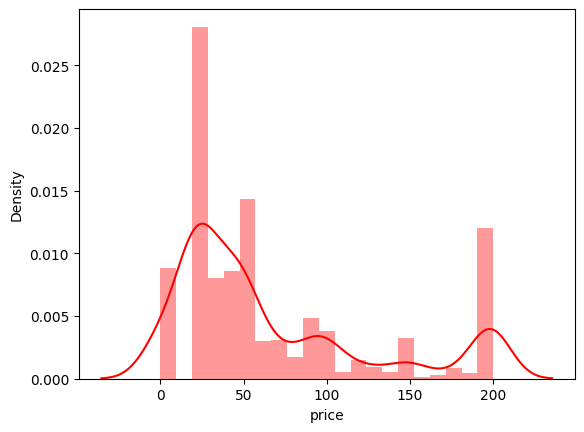

```python
# We can observe that price column is right-skewed as mean is greater than median.
sns.distplot(data['price'],color='r')
plt.show()
```

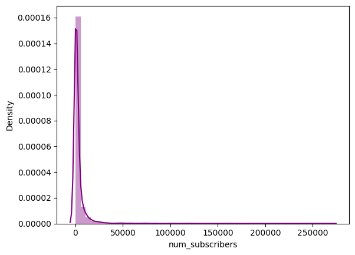

```python
# We can observe that number of subscribers is right-skewed as mean is greater than median.
sns.distplot(data['num_subscribers'],color='purple')
plt.show()
```

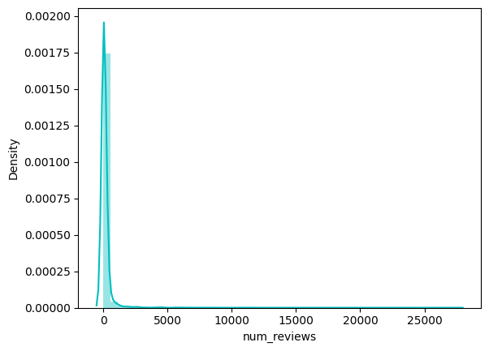

```python
# We can observe that number of reviews is right-skewed as mean is greater than median.
sns.distplot(data['num_reviews'],color='c')
plt.show()
```

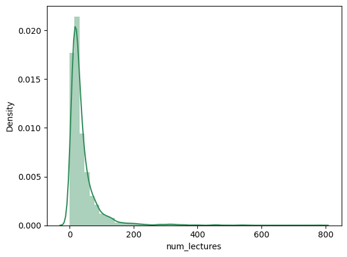

```python
# We can observe that number of lectures is right-skewed as mean is greater than median.
sns.distplot(data['num_lectures'],color='seagreen')
plt.show()
```

Q8) Display Course titles having Content duration greater than 10 hours.

```python
data[data['content_duration']>10][['course_title']]
```

|  | course_title |
| --- | --- |
| 1 | Complete GST Course & Certification - Grow You... |
| 42 | Financial Modeling for Startups & Small Busine... |
| 44 | Black Algo Trading: Build Your Trading Robot |
| 66 | Options Trading Basics (3-Course Bundle) |
| 82 | Introduction to Accounting: The Language of Bu... |
| ... | ... |
| 3618 | jQuery UI Ultimate:Design Amazing Interfaces U... |
| 3635 | WordPress Development - Themes, Plugins & Sing... |
| 3650 | HTML and CSS: A Guide to Web Design |
| 3658 | The Complete Web Developer Course - Build 20 W... |
| 3672 | jQuery UI in Action: Build 5 jQuery UI Projects |

289 rows × 1 columns

```python
# We can observe that there are 289 courses having Content duration greater than 10 hours.
```

Q9) Which subject has the highest average number of subscribers?

```python
a=data.groupby('subject')
b=pd.DataFrame(a['num_subscribers'].mean())
b
```

| subject | num_subscribers |
| --- | --- |
| Business Finance | 1563.774895 |
| Graphic Design | 1763.097844 |
| Musical Instruments | 1245.130882 |
| Web Development | 6650.476667 |

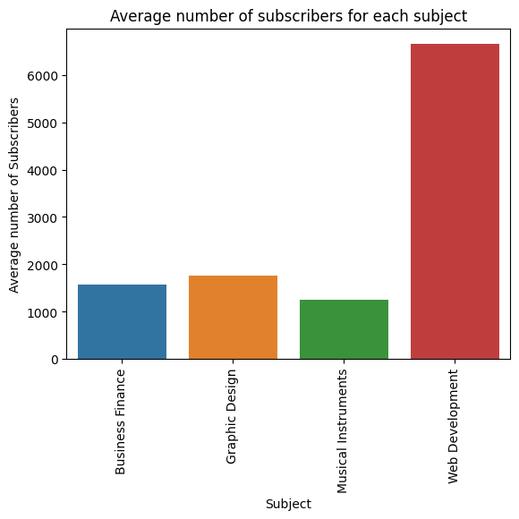

```python
sns.barplot(x=b.index,y=b['num_subscribers'])
plt.xlabel('Subject')
plt.ylabel('Average number of Subscribers')
plt.title('Average number of subscribers for each subject')
plt.xticks(rotation=90)
plt.show()
```

```python
# We can observe that subject Web Development has the highest average number of subscribers.
```

Q10) Which subject has the highest average number of reviews?

```python
c=pd.DataFrame(a['num_reviews'].mean())
c
```

| subject | num_reviews |
| --- | --- |
| Business Finance | 63.516318 |
| Graphic Design | 61.475954 |
| Musical Instruments | 46.652941 |
| Web Development | 358.354167 |

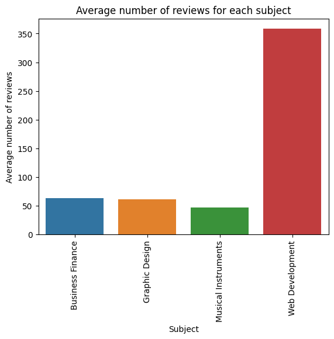

```python
sns.barplot(x=c.index,y=c['num_reviews'])
plt.xlabel("Subject")
plt.ylabel("Average number of reviews")
plt.title("Average number of reviews for each subject")
plt.xticks(rotation=90)
plt.show()
```

```python
# We can observe that subject Web Development has highest average number of reviews.
```

Q11) Display titles of top 5 courses with highest number of subscribers.

```python
num_max_subscribers=data.groupby('course_title')['num_subscribers'].max()
data1=pd.DataFrame(num_max_subscribers.sort_values(ascending=True),columns=['num_subscribers']).tail(5)[::-1]
data1
```

| course_title | num_subscribers |
| --- | --- |
| Learn HTML5 Programming From Scratch | 268923 |
| Coding for Entrepreneurs Basic | 161029 |
| The Web Developer Bootcamp | 121584 |
| Build Your First Website in 1 Week with HTML5 and CSS3 | 120291 |
| The Complete Web Developer Course 2.0 | 114512 |

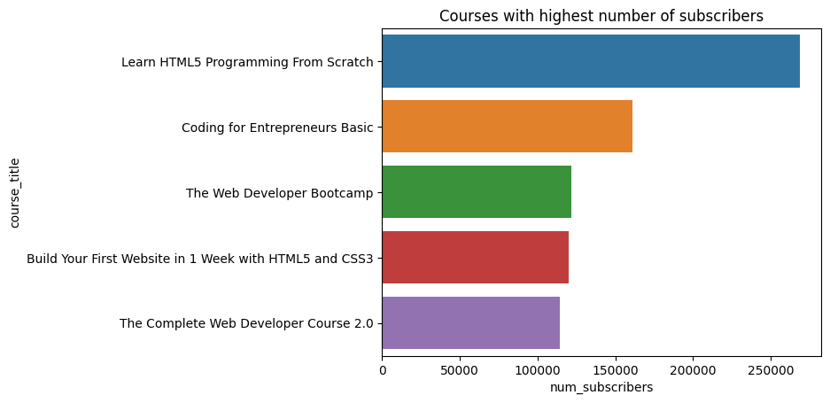

```python
sns.barplot(x=data1['num_subscribers'],y=data1.index)
plt.title("Courses with highest number of subscribers")
plt.show()
```

Q12) Display titles of top 5 courses with highest number of reviews.

```python
num_max_reviews=data.groupby('course_title')['num_reviews'].max()
data2=pd.DataFrame(num_max_reviews.sort_values(ascending=True),columns=['num_reviews']).tail(5)[::-1]
data2
```

| course_title | num_reviews |
| --- | --- |
| The Web Developer Bootcamp | 27445 |
| The Complete Web Developer Course 2.0 | 22412 |
| Angular 4 (formerly Angular 2) - The Complete Guide | 19649 |
| JavaScript: Understanding the Weird Parts | 16976 |
| Modern React with Redux | 15117 |

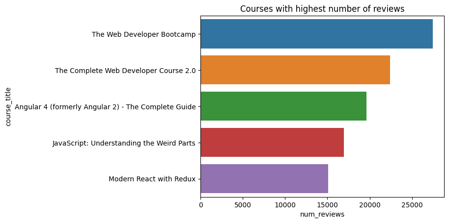

```python
sns.barplot(x=data2['num_reviews'],y=data2.index)
plt.title('Courses with highest number of reviews')
plt.show()
```

Q13) Display percentage of free and paid courses.

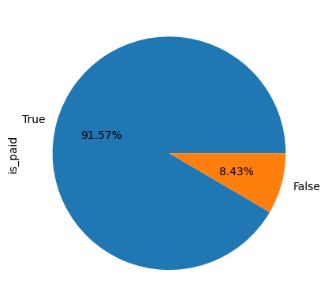

```python
data['is_paid'].value_counts().plot(kind='pie',autopct="%.2f%%")
plt.show()
```

```python
# We can observe that 91.57% courses are paid while 8.43% courses are free.
```

Q14) Display percentage of courses based on level of difficulty.

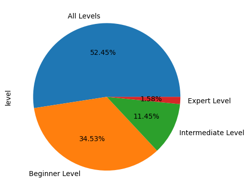

```python
data['level'].value_counts().plot(kind="pie",autopct="%.2f%%")
plt.show()
```

```python
# We can observe that 52.45% courses are suitable for all levels, 34.53% courses are suitable for beginner level,
# 11.45% courses are suitable for intermediate level and 1.58% courses are suitable for high level.
```

Q15) Display top 10 courses with the highest number of lectures.

```python
num_max_lectures=data.groupby('course_title')['num_lectures'].max()
data3=pd.DataFrame(num_max_lectures.sort_values(ascending=True),columns=['num_lectures']).tail(10)[::-1]
data3
```

| course_title | num_lectures |
| --- | --- |
| Back to School Web Development and Programming Bundle | 779 |
| Learn to Trade The News | 544 |
| Thoughtful Web Development Course: HTML, Vue.js, PHP, MySQL | 536 |
| Financial Management - A Complete Study | 527 |
| Code & Grow Rich: Earn More As An Entrepreneur Or Developer | 491 |
| Advanced Accounting A Complete Study for CA / CMA / CFA / CS | 462 |
| MCA Accountancy and Financial Management -Paper MCS 35 IGNOU | 460 |
| Learn to build 20 websites and build 14 iOS9 apps with swift | 458 |
| Become a Professional Web Developer \| Version 3.0 | 454 |
| Cost Accounting and Financial Management - A Complete Study | 444 |

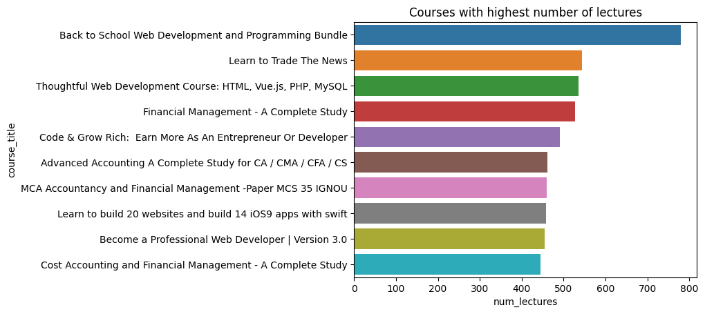

```python
sns.barplot(x=data3['num_lectures'],y=data3.index)
plt.title("Courses with highest number of lectures")
plt.show()
```

Q16) Display top 5 intermediate level courses having highest number of reviews.

```python
num_of_reviews=data[data['level']=='Intermediate Level'].sort_values(by='num_reviews',ascending=False).head(5)
data4=pd.DataFrame(num_of_reviews)
data4
```

|  | course_id | course_title | url | is_paid | price | num_subscribers | num_reviews | num_lectures | level | content_duration | published_timestamp | subject |
| --- | --- | --- | --- | --- | --- | --- | --- | --- | --- | --- | --- | --- |
| 3253 | 781532 | Advanced React and Redux | https://www.udemy.com/react-redux-tutorial/ | True | 140 | 21998 | 3326 | 119 | Intermediate Level | 12.0 | 2016-03-12T22:13:46Z | Web Development |
| 1983 | 484670 | Guitar Super System Level 1 | https://www.udemy.com/guitar-super-system-leve... | True | 50 | 10869 | 2257 | 104 | Intermediate Level | 5.0 | 2015-04-29T23:49:34Z | Musical Instruments |
| 119 | 151668 | Introduction to Financial Modeling | https://www.udemy.com/financial-modeling-asimp... | False | 0 | 29167 | 1463 | 8 | Intermediate Level | 1.5 | 2014-05-27T16:22:16Z | Business Finance |
| 2512 | 670034 | Advanced Javascript | https://www.udemy.com/top-javascript-interview... | True | 200 | 6601 | 1304 | 26 | Intermediate Level | 3.5 | 2015-11-21T06:56:33Z | Web Development |
| 3539 | 309820 | ASP.Net MVC Quick Start | https://www.udemy.com/aspnet-mvc-quick-start/ | False | 0 | 15092 | 1234 | 65 | Intermediate Level | 5.5 | 2016-08-23T15:59:10Z | Web Development |

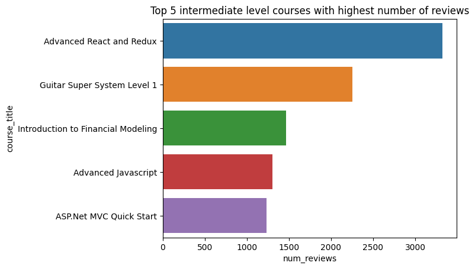

```python
sns.barplot(x=data4['num_reviews'],y=data4['course_title'])
plt.title('Top 5 intermediate level courses with highest number of reviews')
plt.show()
```

Q17) Display courses that were published in 2017.

```python
data[data['published_timestamp'].str.contains("2017")]
```

|  | course_id | course_title | url | is_paid | price | num_subscribers | num_reviews | num_lectures | level | content_duration | published_timestamp | subject |
| --- | --- | --- | --- | --- | --- | --- | --- | --- | --- | --- | --- | --- |
| 0 | 1070968 | Ultimate Investment Banking Course | https://www.udemy.com/ultimate-investment-bank... | True | 200 | 2147 | 23 | 51 | All Levels | 1.5 | 2017-01-18T20:58:58Z | Business Finance |
| 1 | 1113822 | Complete GST Course & Certification - Grow You... | https://www.udemy.com/goods-and-services-tax/ | True | 75 | 2792 | 923 | 274 | All Levels | 39.0 | 2017-03-09T16:34:20Z | Business Finance |
| 3 | 1210588 | Beginner to Pro - Financial Analysis in Excel ... | https://www.udemy.com/complete-excel-finance-c... | True | 95 | 2451 | 11 | 36 | All Levels | 3.0 | 2017-05-30T20:07:24Z | Business Finance |
| 9 | 1167710 | The Only Investment Strategy You Need For Your... | https://www.udemy.com/the-only-investment-stra... | True | 200 | 827 | 14 | 15 | All Levels | 1.0 | 2017-04-18T18:13:32Z | Business Finance |
| 14 | 1196544 | Python Algo Trading: Sentiment Trading with News | https://www.udemy.com/hedge-fund-strategy-trad... | True | 200 | 294 | 19 | 42 | All Levels | 7.0 | 2017-04-28T16:41:44Z | Business Finance |
| ... | ... | ... | ... | ... | ... | ... | ... | ... | ... | ... | ... | ... |
| 3651 | 1079078 | Drupal 8 Site Building | https://www.udemy.com/drupal-8-site-building/ | False | 0 | 1942 | 23 | 48 | All Levels | 4.5 | 2017-05-02T05:15:52Z | Web Development |
| 3652 | 919354 | Learn Bootstrap 4 The Most Popular HTML5 CSS3 ... | https://www.udemy.com/learn-bootstrap-4-the-mo... | True | 200 | 279 | 37 | 119 | All Levels | 10.0 | 2017-04-25T00:57:35Z | Web Development |
| 3653 | 1248172 | Essentials of Spring 5.0 for Developers | https://www.udemy.com/essentials-of-spring-50-... | True | 125 | 34 | 2 | 21 | Expert Level | 1.5 | 2017-06-11T18:34:40Z | Web Development |
| 3664 | 1115064 | XML DTD - Crash Course for Beginners | https://www.udemy.com/xml-dtd-crash-course-for... | True | 45 | 944 | 1 | 10 | All Levels | 1.0 | 2017-02-18T20:21:12Z | Web Development |
| 3674 | 1088178 | How To Design A WordPress Website With No Codi... | https://www.udemy.com/how-to-make-a-wordpress-... | True | 25 | 306 | 3 | 42 | Beginner Level | 3.5 | 2017-03-10T22:24:30Z | Web Development |

715 rows × 12 columns

```python
# We can observe that there were 715 courses that were published in 2017.
```

Q18) Display all courses containing word "Trading".

```python
data[data['course_title'].str.contains("Trading")]
```

|  | course_id | course_title | url | is_paid | price | num_subscribers | num_reviews | num_lectures | level | content_duration | published_timestamp | subject |
| --- | --- | --- | --- | --- | --- | --- | --- | --- | --- | --- | --- | --- |
| 4 | 1011058 | How To Maximize Your Profits Trading Options | https://www.udemy.com/how-to-maximize-your-pro... | True | 200 | 1276 | 45 | 26 | Intermediate Level | 2.0 | 2016-12-13T14:57:18Z | Business Finance |
| 5 | 192870 | Trading Penny Stocks: A Guide for All Levels I... | https://www.udemy.com/trading-penny-stocks-a-g... | True | 150 | 9221 | 138 | 25 | All Levels | 3.0 | 2014-05-02T15:13:30Z | Business Finance |
| 6 | 739964 | Investing And Trading For Beginners: Mastering... | https://www.udemy.com/investing-and-trading-fo... | True | 65 | 1540 | 178 | 26 | Beginner Level | 1.0 | 2016-02-21T18:23:12Z | Business Finance |
| 7 | 403100 | Trading Stock Chart Patterns For Immediate, Ex... | https://www.udemy.com/trading-chart-patterns-f... | True | 95 | 2917 | 148 | 23 | All Levels | 2.5 | 2015-01-30T22:13:03Z | Business Finance |
| 8 | 476268 | Options Trading 3 : Advanced Stock Profit and ... | https://www.udemy.com/day-trading-stock-option... | True | 195 | 5172 | 34 | 38 | Expert Level | 2.5 | 2015-05-28T00:14:03Z | Business Finance |
| ... | ... | ... | ... | ... | ... | ... | ... | ... | ... | ... | ... | ... |
| 1152 | 679238 | Day Trading - Learn to Day Trade / Swing Trade... | https://www.udemy.com/the-123-trading-strategy... | True | 95 | 335 | 25 | 29 | All Levels | 1.5 | 2015-11-27T17:38:51Z | Business Finance |
| 1157 | 521952 | Ultimate Guide To Trading Engulfing Candlestic... | https://www.udemy.com/trading-engulfing-candle... | True | 200 | 185 | 36 | 25 | All Levels | 2.5 | 2016-10-25T02:14:44Z | Business Finance |
| 1162 | 986272 | Hedge Fund Trading Systems For Stocks - Part One | https://www.udemy.com/amibroker-trading-systems/ | True | 200 | 52 | 8 | 21 | All Levels | 1.5 | 2016-10-29T21:56:38Z | Business Finance |
| 1167 | 248338 | Introduction to Day Trading | https://www.udemy.com/introduction-to-day-trad... | True | 50 | 79 | 5 | 36 | Beginner Level | 1.0 | 2014-09-05T04:38:45Z | Business Finance |
| 1173 | 1001010 | Forex Trading: Strategia Correlazione EUR/GBP ... | https://www.udemy.com/forex-trading-strategia-... | True | 50 | 137 | 39 | 27 | Intermediate Level | 1.5 | 2016-11-10T15:10:05Z | Business Finance |

255 rows × 12 columns

```python
# We can observe that there are 255 courses containing word "Trading".
```

Q19) Display all courses containing word "HTML" and have number of lectures greater than 20.

```python
data[(data['course_title'].str.contains("HTML"))&(data['num_lectures']>20)]
```

|  | course_id | course_title | url | is_paid | price | num_subscribers | num_reviews | num_lectures | level | content_duration | published_timestamp | subject |
| --- | --- | --- | --- | --- | --- | --- | --- | --- | --- | --- | --- | --- |
| 2478 | 28295 | Learn Web Designing & HTML5/CSS3 Essentials in... | https://www.udemy.com/build-beautiful-html5-we... | True | 75 | 43285 | 525 | 24 | All Levels | 4.0 | 2013-01-03T00:55:31Z | Web Development |
| 2481 | 197836 | Projects in HTML5 | https://www.udemy.com/projects-in-html5/ | True | 60 | 8777 | 206 | 75 | Intermediate Level | 15.5 | 2014-06-17T05:43:50Z | Web Development |
| 2482 | 505208 | Programming Foundations: HTML5 + CSS3 for Entr... | https://www.udemy.com/html-css-more/ | True | 20 | 23764 | 490 | 58 | Beginner Level | 5.5 | 2015-10-17T04:52:25Z | Web Development |
| 2491 | 8325 | HTML Tutorial: HTML & CSS for Beginners | https://www.udemy.com/learn-html5/ | True | 20 | 12458 | 253 | 82 | All Levels | 4.0 | 2011-09-09T15:28:59Z | Web Development |
| 2494 | 159070 | Introduction to Web Development: HTML | https://www.udemy.com/webdevelopment101_html/ | True | 20 | 26800 | 333 | 55 | Beginner Level | 3.0 | 2014-02-13T20:39:33Z | Web Development |
| ... | ... | ... | ... | ... | ... | ... | ... | ... | ... | ... | ... | ... |
| 3650 | 516790 | HTML and CSS: A Guide to Web Design | https://www.udemy.com/html-and-css-a-guide-to-... | True | 25 | 1557 | 13 | 74 | All Levels | 14.0 | 2015-06-02T22:41:13Z | Web Development |
| 3652 | 919354 | Learn Bootstrap 4 The Most Popular HTML5 CSS3 ... | https://www.udemy.com/learn-bootstrap-4-the-mo... | True | 200 | 279 | 37 | 119 | All Levels | 10.0 | 2017-04-25T00:57:35Z | Web Development |
| 3660 | 747650 | Learn HTML, CSS, and Ruby on Rails: Build Your... | https://www.udemy.com/learn-html-css-and-ruby-... | True | 20 | 2985 | 40 | 27 | Beginner Level | 1.5 | 2016-11-29T23:41:06Z | Web Development |
| 3661 | 761770 | Learn HTML5 Canvas for beginners | https://www.udemy.com/learn-html5-canvas-for-b... | True | 100 | 2360 | 12 | 49 | Beginner Level | 3.5 | 2016-03-01T17:53:34Z | Web Development |
| 3665 | 21386 | Beginner Photoshop to HTML5 and CSS3 | https://www.udemy.com/psd-html5-css3/ | False | 0 | 73110 | 1716 | 22 | All Levels | 2.0 | 2012-07-27T12:54:57Z | Web Development |

120 rows × 12 columns

```python
# We can observe that there are 120 courses containing word "HTML" and have number of lectures greater than 20.
```

Q20) Display all Web development courses that were published in 2016.

```python
data[(data['subject']=='Web Development')&(data['published_timestamp'].str.contains("2016"))]
```

|  | course_id | course_title | url | is_paid | price | num_subscribers | num_reviews | num_lectures | level | content_duration | published_timestamp | subject |
| --- | --- | --- | --- | --- | --- | --- | --- | --- | --- | --- | --- | --- |
| 2480 | 889438 | ChatBots: Messenger ChatBot with API.AI and No... | https://www.udemy.com/chatbots/ | True | 50 | 2577 | 529 | 64 | All Levels | 4.500000 | 2016-06-30T16:57:08Z | Web Development |
| 2485 | 965870 | Angular and Firebase - Build a Web App with Ty... | https://www.udemy.com/angular-firebase-applica... | True | 150 | 1966 | 359 | 65 | All Levels | 5.000000 | 2016-09-27T21:46:03Z | Web Development |
| 2486 | 965528 | Web Development Masterclass - Complete Certifi... | https://www.udemy.com/web-development-mastercl... | True | 200 | 4090 | 178 | 348 | All Levels | 19.500000 | 2016-10-12T03:14:13Z | Web Development |
| 2489 | 785388 | Scaling Docker on AWS | https://www.udemy.com/scaling-docker-on-aws/ | True | 25 | 3133 | 351 | 63 | All Levels | 6.000000 | 2016-03-28T17:51:04Z | Web Development |
| 2492 | 987064 | Learn by Doing: Vue JS 2.0 the Right Way | https://www.udemy.com/learn-by-doing-vue-js-2-... | True | 95 | 1087 | 220 | 32 | Intermediate Level | 3.500000 | 2016-11-07T17:53:40Z | Web Development |
| ... | ... | ... | ... | ... | ... | ... | ... | ... | ... | ... | ... | ... |
| 3663 | 1036028 | Build Wordpress CMS Clone with Laravel 5 | https://www.udemy.com/build-blog-cms-with-lara... | True | 150 | 392 | 81 | 63 | All Levels | 8.500000 | 2016-12-19T22:00:20Z | Web Development |
| 3666 | 968292 | XPATH :basics for beginners | https://www.udemy.com/xpath-basics-for-beginners/ | True | 40 | 878 | 6 | 8 | All Levels | 0.616667 | 2016-09-27T15:20:47Z | Web Development |
| 3672 | 865438 | jQuery UI in Action: Build 5 jQuery UI Projects | https://www.udemy.com/jquery-ui-practical-buil... | True | 150 | 382 | 28 | 140 | All Levels | 15.500000 | 2016-10-10T22:00:32Z | Web Development |
| 3673 | 775618 | Learn jQuery from Scratch - Master of JavaScri... | https://www.udemy.com/easy-jquery-for-beginner... | True | 100 | 1040 | 14 | 21 | All Levels | 2.000000 | 2016-06-14T17:36:46Z | Web Development |
| 3676 | 905096 | CSS Animations: Create Amazing Effects on Your... | https://www.udemy.com/css-animations-create-am... | True | 50 | 300 | 31 | 38 | All Levels | 3.000000 | 2016-08-11T19:06:15Z | Web Development |

448 rows × 12 columns

```python
# We can observe that there were 448 Web development courses that were published in 2016.
```

Q21) Create scatterplot between price and number of subscribers.

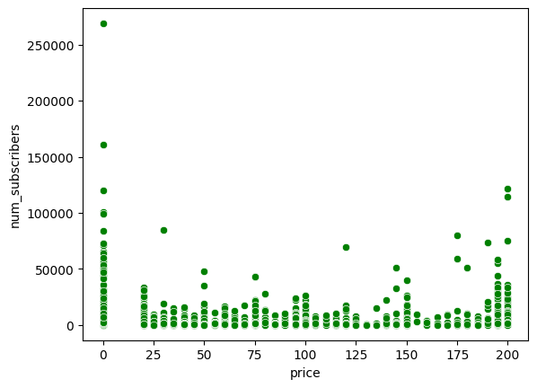

```python
sns.scatterplot(x=data['price'],y=data['num_subscribers'],c='green')
plt.show()
```

Q22) Create scatterplot between price and content duration.

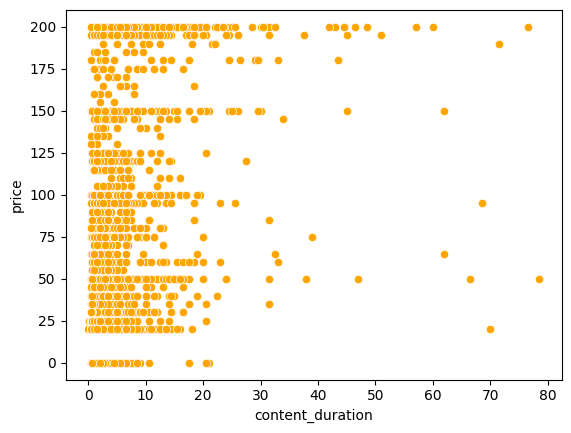

```python
sns.scatterplot(x=data['content_duration'],y=data['price'],c='orange')
plt.show()
```

Q23) Create a heatmap to find correlation between numerical columns.

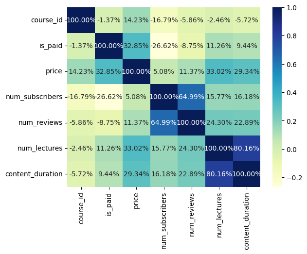

```python
sns.heatmap(data.corr(),annot=True,fmt=".2%",cmap='YlGnBu')
plt.show()
```

Q24) Create countplot for level column.

```python
cat_col
```

```
Index(['course_title', 'url', 'level', 'published_timestamp', 'subject'], dtype='object')
```

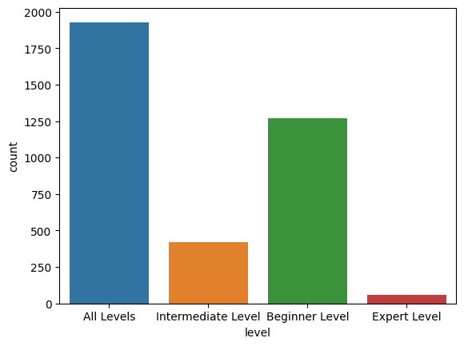

```python
sns.countplot(x=data['level'])
plt.show()
```

```python
# We can observe that there are more number of courses suitable for all levels.
```

Q25) Create a pairplot for the given dataset.

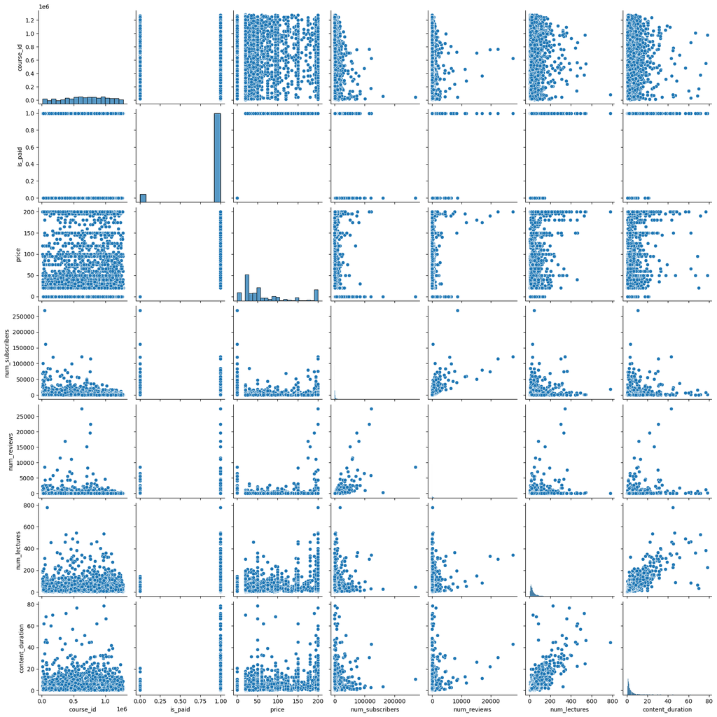

```python
sns.pairplot(data)
plt.show()
```

Q26) Create Countplot for subject column.

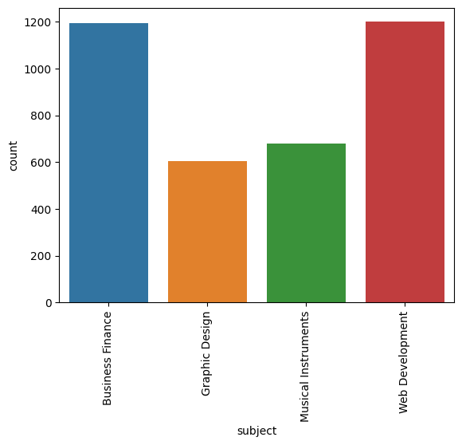

```python
sns.countplot(x=data['subject'])
plt.xticks(rotation=90)
plt.show()
```

```python
# We can observe that Business Finance and Web development almost have same number of courses.
```